# Sessenta Anos Depois: Teses, Programas e Agendas da Ciência Política no Brasil

Institucionalização, expansão da pós-graduação e diversificação temática

Vitor Peixoto — UENF

2026-09-02

## Sessenta anos depois, quanto do que chamamos de “expansão da Ciência Política” é, de fato, Ciência Política?

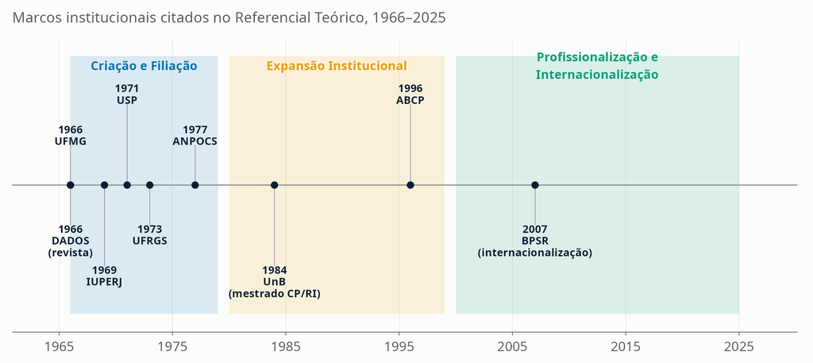

## A pós-graduação como motor de autonomização

- A institucionalização da Ciência Política no Brasil não veio da graduação: foi puxada de cima para baixo pelo sistema de avaliação e fomento da CAPES (Leite and Codato 2013)
- A criação da Área 39 deu ao campo critérios próprios de produtividade (Qualis Periódicos) e metas de titulação
- Mas a expansão foi mais lenta que a das áreas irmãs: até a virada do milênio, um “déficit de doutores” atrasou a criação de novos centros fora do eixo Sudeste (Marenco 2014)
- Diferença de origem: Geografia e História cresceram puxadas pela demanda de professores para a educação básica; a Ciência Política nasceu voltada à pesquisa avançada — daí sua menor capilaridade inicial

## O “calcanhar metodológico” ganhou infraestrutura

- Soares (2005) diagnosticou a carência de treinamento empírico formal. A resposta institucional mais duradoura **antecede o diagnóstico**
- **MQ² (UFMG, 1999)**: nasceu na Sociologia, não na Ciência Política — a formação quantitativa chegou à Área 39 por uma porta lateral, compartilhada com uma área irmã
- **IPSA-USP Summer School (2010)**: a primeira escola de verão da IPSA no mundo; 87 participantes na 1ª edição, 225 em 2016
- Mas a trajetória **não é ascendente contínua**: o MODUS (escola própria do PPGCP-UFMG) durou de 2017 a 2022, e a IPSA-USP não teve edições em 2022, 2023 e 2026

## O sistema cresceu 39 vezes em quatro décadas

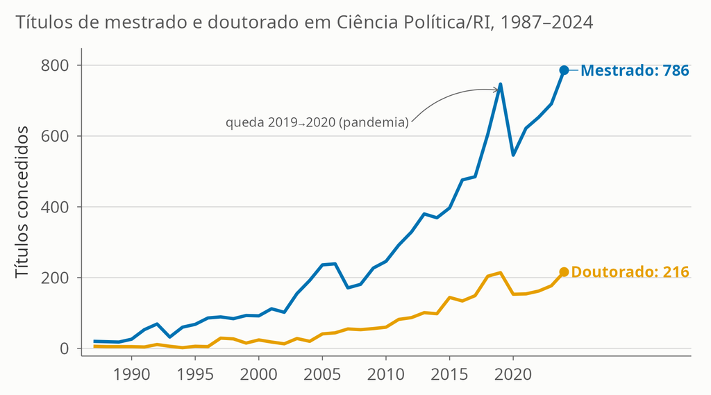

## …e se espalhou pelo território

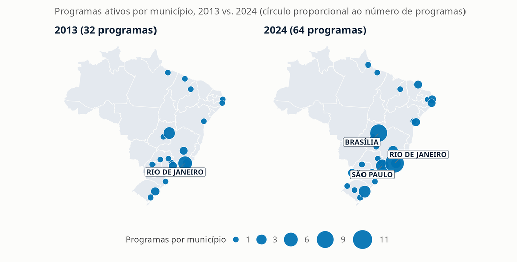

Municípios com programas: 20 (2013) → 29 (2024). Participação do Sudeste: 46,9% → 43,8%.

## Não é a menor área. É a menos capilar.

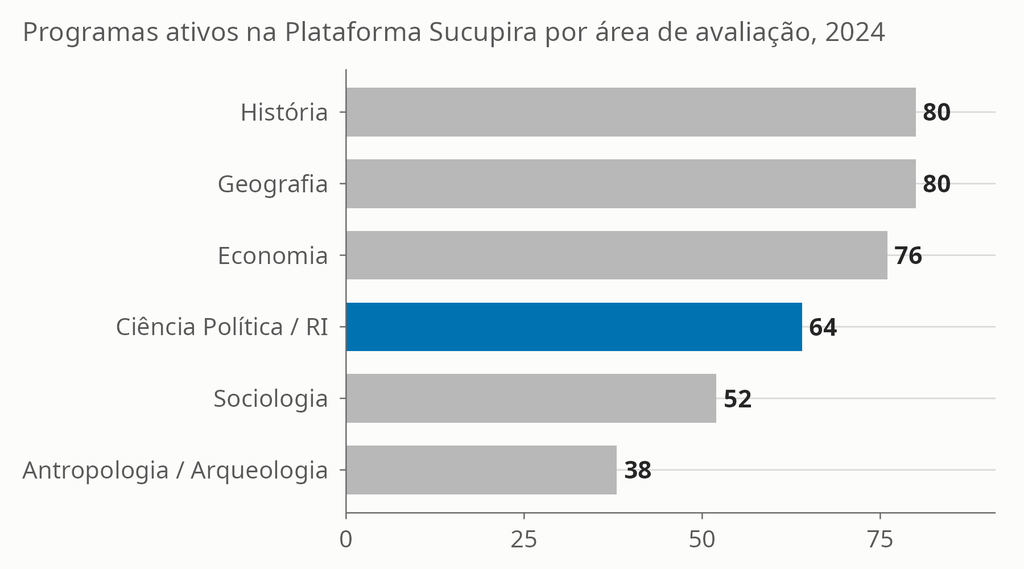

64 programas em 2024: a **4ª de seis**. Presente em **15 UFs**, a menor cobertura do grupo. Cresceu **100%** em programas entre 2013 e 2024, mais que qualquer irmã.

## O crescimento recente é o mais rápido das seis áreas

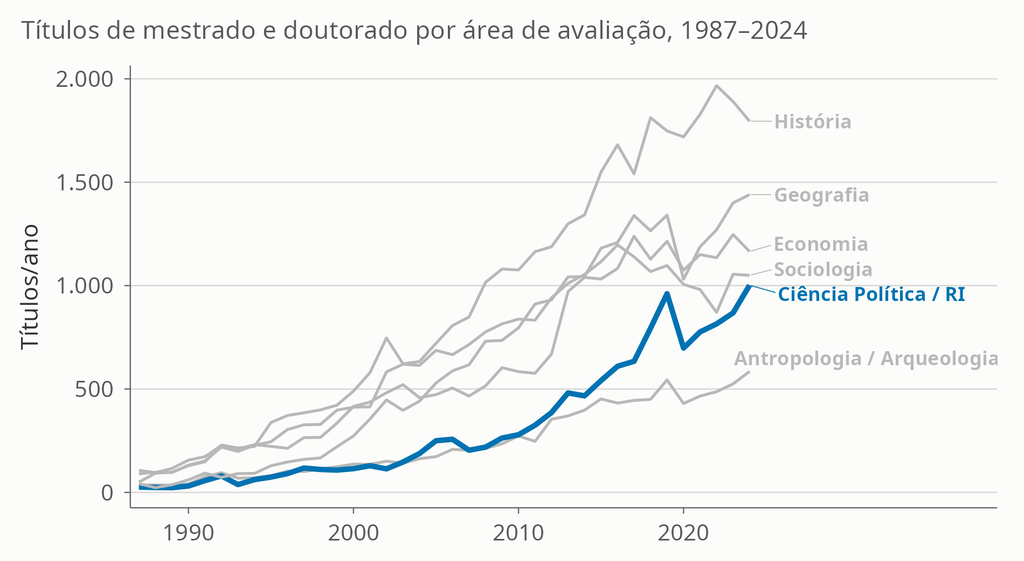

**Títulos, crescimento composto ao ano (2015–2024):**

- Ciência Política/RI: **7,1%**
- Antropologia: 2,9%
- Geografia: 2,2%
- História: 1,7%
- Economia: 1,4%
- Sociologia: -0,7%

Em volume, a distância persiste: 1.002 títulos em 2024, contra 1.795 da História.

## Programas menores, titulação menos intensa

[figure not shown]

### O achado central

## A Área 39 não é a Ciência Política

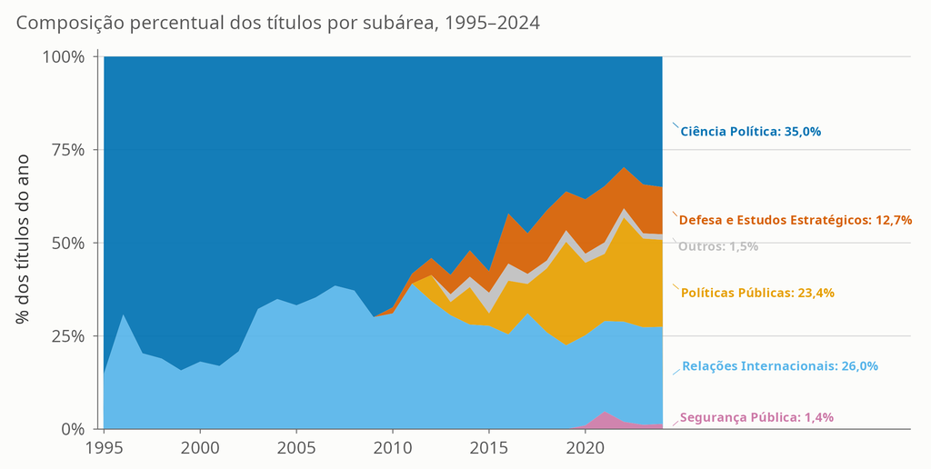

## Defesa e Segurança Pública: dois campos novos, não um

- Primeiro título de defesa registrado em **2010**; **1.033 títulos** acumulados até 2024
- Em 2024: **8 programas de defesa** e **2 de segurança pública**, contra **21 de Ciência Política estrita**
- A segurança pública é contada à parte: policiamento e sistema prisional não partilham objeto nem literatura com estudos estratégicos militares
- Hibridização com a *policy science* e os estudos estratégicos — e em boa medida na **modalidade profissional**: 31,2% dos programas da área, a maior proporção das seis

## Mais mulheres — mas não no doutorado

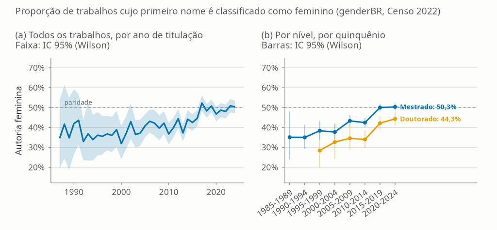

## A teoria política recuou — e só isso o dado sustenta

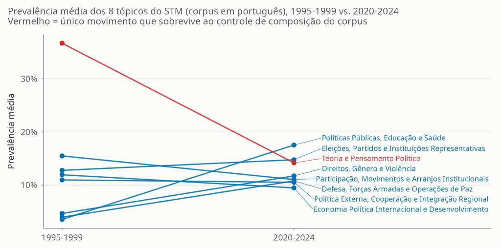

## Nos encontros, a área não está em último lugar

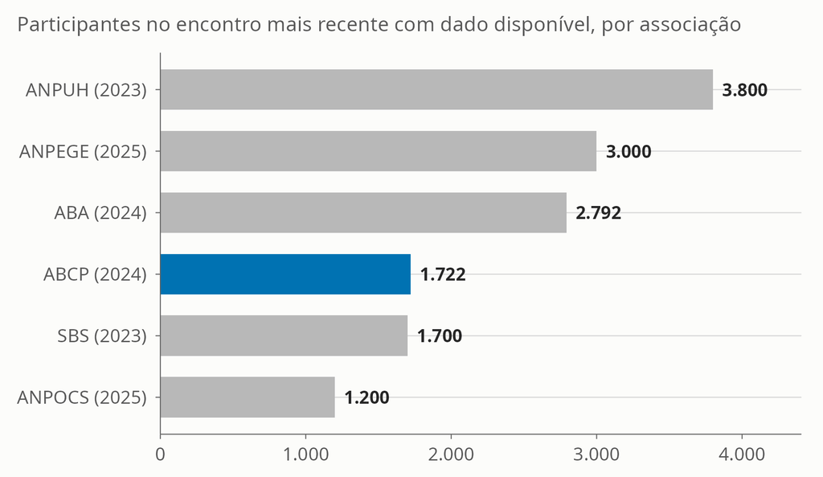

## O que isto não mostra

1. **Mudança metodológica**: descrevemos diversificação *temática*, não desenhos de pesquisa. Uma extensão futura deve classificar explicitamente os métodos usados nos trabalhos.
2. **Causalidade**: a expansão é compatível com a indução pela política de pós-graduação, mas não há contrafactual, nem observação de editais, bolsas ou decisões de avaliação.
3. **Comparabilidade perfeita**: áreas de avaliação da CAPES não são disciplinas; os dois layouts históricos do catálogo (1987–2012 e 2013–2024) exigiram âncoras de filtro distintas; a cobertura do OpenAlex é desigual entre periódicos.
4. **Medida de gênero**: imputada por nome, binária por construção e probabilística — não mede identidade. O corpo docente segue sem essa informação nos microdados.
5. **Dados ausentes**: sem trajetória completa dos egressos; sem comparação de colaboração internacional entre áreas.

## Conclusão

1. **Não é uma área pequena: é uma área concentrada.** Com 64 programas, é a 4ª de seis — mas está em apenas 15 UFs, a menor cobertura territorial do grupo, e foi a que mais cresceu entre 2013 e 2024.
2. **A área é híbrida.** Só 35,0% dos títulos de 2024 vêm de Ciência Política estrita; o resto é Relações Internacionais, Políticas Públicas e dois campos novos — Defesa e Segurança Pública. E 31,2% dos programas são profissionais, a maior proporção das seis áreas.
3. **A agenda mudou, mas o dado sustenta menos do que parece.** A retração da teoria política resiste ao controle de composição do corpus; a ascensão das demais agendas, não.
4. **A autoria feminina se aproximou da paridade sem alcançá-la**, e o hiato entre mestrado e doutorado é de 6,0 pontos percentuais no último quinquênio.

Sessenta anos depois da criação dos primeiros programas, o retrato é de uma disciplina territorialmente concentrada, internamente híbrida e em expansão rápida — sem que isso permita atribuir o crescimento a uma política específica.

### Obrigado

**Vitor Peixoto — UENF**

## Reprodutibilidade

- **GitHub:** https://github.com/moraespeixoto/trajetoria_CP_Brasil
- **Repositório local:** `/dados/trajetoria_CP_Brasil`
- **Pipeline:** `SCRIPTS/01` a `SCRIPTS/22`, testes de regressão em `SCRIPTS/99`; artigo em `artigo_historia_cp_brasil.qmd`
- **Auditoria de dados:** `AUDITORIA.md`
- **Semente aleatória:** `20260828`

### Referências citadas nesta apresentação

- Forjaz, M. C. S. (1997). *A emergência da Ciência Política acadêmica no Brasil: aspectos institucionais*. RBCS. (Forjaz 1997)
- Lamounier, B. (1989). *A ciência política nos anos 70*. Em: *História das Ciências Sociais no Brasil*. (Lamounier 1989)
- Leite, F. & Codato, A. (2013). *Autonomização e institucionalização da Ciência Política brasileira: o papel do sistema Qualis-Capes*. (Leite and Codato 2013)
- Marenco, A. (2014). *The Three Achilles’ Heels of Brazilian Political Science*. BPSR. (Marenco 2014)
- Meireles, F. (2026). *genderBR: Predict Gender from Brazilian First Names*. Pacote R. (Meireles 2026)
- Roberts, M. E. et al. (2014). *Structural Topic Models for Open-Ended Survey Responses*. AJPS. (Roberts et al. 2014)
- Soares, G. A. D. (2005). *O calcanhar metodológico da ciência política no Brasil*. Sociologia, Problemas e Práticas. (Soares 2005)